# Covariance-Based IBR with wishart_covariance

Bill Peterman

## 1 Overview

The standard `terradish` workflow uses a pre-computed **distance matrix** (e.g. F<sub>ST</sub>) as the genetic response. Two measurement models, `leastsquares` and `mlpe`, accept such matrices and differ only in how they handle the non-independence of pairwise observations.

When raw individual-level genotype data are available, you can retain a population covariance summary rather than beginning from a precomputed distance matrix:

1. Summarize the genetic data as a **covariance matrix** between populations.
2. Fit the resistance model with `wishart_covariance`, using a declared effective degrees of freedom, `nu`.

Both Wishart interfaces use the **contrast likelihood**. For an orthonormal site-contrast matrix `Q`, the covariance likelihood uses `Q' S Q` and the corresponding fitted contrast covariance. Components in the constant-site direction are excluded. Centering `S` therefore leaves this likelihood unchanged. The previous full-rank formulation was removed because that constant direction depends on arbitrary centering conventions and does not provide the intended resistance information.

`dist_from_cov(S)` retains the covariance information used by this likelihood. Covariance and matching squared-distance inputs are two representations of the same contrast model. Neither is inherently more informative. Begin with `vignette("getting-started", package = "terradish")` for the graph workflow.

| Model | Input `S` | Requires `nu` | Correlation structure |
| --- | --- | --- | --- |
| `leastsquares` | distance matrix | no | none |
| `mlpe` | distance matrix | no | shared-site |
| `generalized_wishart` | admissible squared-distance matrix | yes | generalized Wishart |
| `wishart_covariance` | **covariance matrix** | yes | Wishart |

This vignette covers:

- Converting different types of raw genetic data to a covariance matrix with `cov_from_genetic_data()` (and `cov_from_biallelic()` for biallelic SNPs).
- Setting up the landscape and conductance surface with the bundled *Melipona* data.
- Fitting an IBR model with `wishart_covariance`.
- Interpreting and comparing the fitted model.

## 2 Preparing genetic covariance data

`terradish` provides two functions for turning raw genotype data into a covariance matrix:

- **`cov_from_biallelic(Y, N)`**: fast path for biallelic SNP count matrices.
- **`cov_from_genetic_data(x, ...)`**: flexible path that handles biallelic dosage, multiallelic SNPs, microsatellite allele calls, PCA scores, or any other numeric encoding.

Both functions return a square, symmetric covariance matrix (one row/column per population). Check the construction, sampling design, site order, and covariance geometry before using the matrix as response `S`. The helpers are provided by the companion `landgraph` package.

### 2.1 Biallelic SNPs: `cov_from_biallelic()`

If your data are derived-allele counts at biallelic loci, use `cov_from_biallelic()`:

```r
library(terradish)

# Simulated counts: 4 populations, 5 biallelic loci
# Y[i, l] = number of derived alleles in population i at locus l
# N[i, l] = total haploid chromosomes sampled (here, 20 diploids → N = 40)
set.seed(42)
n_pop <- 4
n_loci <- 5
Y <- matrix(sample(0:40, n_pop * n_loci, replace = TRUE),
            nrow = n_pop, ncol = n_loci,
            dimnames = list(paste0("pop", seq_len(n_pop)),
                            paste0("snp", seq_len(n_loci))))
N <- matrix(40L, nrow = n_pop, ncol = n_loci)

S_biallelic <- cov_from_biallelic(Y, N)
round(S_biallelic, 3)
```

```
#>        pop1    pop2    pop3   pop4
#> pop1 13.663  -9.789   4.626 -8.500
#> pop2 -9.789  15.871 -10.251  4.169
#> pop3  4.626 -10.251   9.071 -3.446
#> pop4 -8.500   4.169  -3.446  7.778
#> attr(,"diagonal")
#> [1] "normalized_dosage"
#> attr(,"centered")
#> [1] "sites"
```

Biallelic standardization can give rare variants large influence. Apply and report a defensible minor-allele-frequency filter, then examine sensitivity to that filter. Unequal chromosome counts also produce unequal sampling variance across populations; a common nugget does not remove that concern. Covariance metadata describe the construction, not proof of Wishart sampling.

### 2.2 Numeric feature matrix: `cov_from_genetic_data()`

For dosage-coded SNPs, PCA scores, or any numeric feature matrix, use `cov_from_genetic_data()` with `input = "features"` (the default). The function centers and scales each feature, then applies Gower double-centering to produce a covariance matrix:

```r
# Individual-level PCA scores: 12 individuals across 4 populations, 3 PCs
set.seed(7)
pca_scores <- matrix(rnorm(12 * 3), nrow = 12, ncol = 3,
                     dimnames = list(NULL, c("PC1", "PC2", "PC3")))
groups <- rep(c("pop1", "pop2", "pop3", "pop4"), each = 3)

S_pca <- cov_from_genetic_data(pca_scores, groups = groups)
round(S_pca, 3)
```

```
#>        pop1   pop2   pop3   pop4
#> pop1  1.867 -0.898  0.014 -0.983
#> pop2 -0.898  1.312  0.016 -0.429
#> pop3  0.014  0.016  0.016 -0.045
#> pop4 -0.983 -0.429 -0.045  1.457
#> attr(,"centroids")
#>              PC1         PC2         PC3
#> pop1 -0.15381677  0.91776505  1.00042794
#> pop2 -0.81717761 -0.71202657 -0.37035279
#> pop3 -0.05949646  0.08389281 -0.07211822
#> pop4  1.03049085 -0.28963130 -0.55795693
#> attr(,"unit_features")
#>              PC1         PC2         PC3
#> pop1 -0.15381677  0.91776505  1.00042794
#> pop2 -0.81717761 -0.71202657 -0.37035279
#> pop3 -0.05949646  0.08389281 -0.07211822
#> pop4  1.03049085 -0.28963130 -0.55795693
#> attr(,"within_variance")
#>     pop1     pop2     pop3     pop4
#> 3.433532 1.731330 1.669228 2.688476
#> attr(,"centroid_distance2")
#>          pop1     pop2     pop3     pop4
#> pop1 0.000000 4.975308 1.854594 5.288954
#> pop2 4.975308 0.000000 1.296512 3.627492
#> pop3 1.854594 1.296512 0.000000 1.563632
#> pop4 5.288954 3.627492 1.563632 0.000000
#> attr(,"unit_distance2")
#>          pop1     pop2     pop3     pop4
#> pop1 0.000000 4.975308 1.854594 5.288954
#> pop2 4.975308 0.000000 1.296512 3.627492
#> pop3 1.854594 1.296512 0.000000 1.563632
#> pop4 5.288954 3.627492 1.563632 0.000000
#> attr(,"unit_size")
#> pop1 pop2 pop3 pop4
#>    3    3    3    3
#> attr(,"feature_center")
#>        PC1        PC2        PC3
#> 0.34279122 0.51787445 0.03662061
#> attr(,"feature_scale")
#>       PC1       PC2       PC3
#> 1.3700081 1.0706866 0.6995432
#> attr(,"retained_features")
#> [1] "PC1" "PC2" "PC3"
#> attr(,"input")
#> [1] "features"
#> attr(,"level")
#> [1] "population"
#> attr(,"diagonal")
#> [1] "gower"
#> attr(,"centered")
#> [1] "sites"
#> attr(,"normalize")
#> [1] "none"
#> attr(,"normalizer")
#> [1] 1
```

Setting `normalize = "features"` divides the covariance by the number of retained features; this puts the scale on a per-feature basis rather than summed across all features, which can make `tau` estimates easier to interpret across datasets with different numbers of markers. This normalization changes the scale of `S`; it does not automatically determine the best `nu` for every genotyping system.

### 2.3 Microsatellite allele calls: `cov_from_genetic_data()` with `input = "allele_calls"`

For diploid microsatellite data stored as two allele-call columns per locus, set `input = "allele_calls"` and supply the `loci` argument to identify which column belongs to which locus. The function expands each locus into per-allele dosage columns before computing covariance:

```r
# 9 individuals, 2 microsatellite loci, each stored in two allele-call columns
alleles <- data.frame(
  loc1_a = c(100, 100, 102, 102, 104, 104, 100, 102, 104),
  loc1_b = c(100, 102, 102, 104, 104, 100, 104, 100, 102),
  loc2_a = c(200, 202, 200, 202, 204, 204, 200, 204, 202),
  loc2_b = c(202, 202, 204, 204, 204, 200, 202, 200, 204)
)
groups_ms <- rep(c("popA", "popB", "popC"), each = 3)
loci_ms <- c("loc1", "loc1", "loc2", "loc2")

S_ms <- cov_from_genetic_data(
  alleles,
  groups  = groups_ms,
  input   = "allele_calls",
  loci    = loci_ms
)
round(S_ms, 3)
```

```
#>        popA   popB   popC
#> popA  2.044 -2.200  0.156
#> popB -2.200  2.428 -0.228
#> popC  0.156 -0.228  0.072
#> attr(,"centroids")
#>           loc1:100      loc1:102      loc1:104   loc2:200      loc2:202
#> popA  4.714045e-01  4.714045e-01 -9.428090e-01  0.2108185  4.714045e-01
#> popB -4.714045e-01 -4.714045e-01  9.428090e-01 -0.4216370 -4.714045e-01
#> popC  3.700743e-17  3.700743e-17  3.700743e-17  0.2108185  3.700743e-17
#>        loc2:204
#> popA -0.6666667
#> popB  0.8333333
#> popC -0.1666667
#> attr(,"unit_features")
#>           loc1:100      loc1:102      loc1:104   loc2:200      loc2:202
#> popA  4.714045e-01  4.714045e-01 -9.428090e-01  0.2108185  4.714045e-01
#> popB -4.714045e-01 -4.714045e-01  9.428090e-01 -0.4216370 -4.714045e-01
#> popC  3.700743e-17  3.700743e-17  3.700743e-17  0.2108185  3.700743e-17
#>        loc2:204
#> popA -0.6666667
#> popB  0.8333333
#> popC -0.1666667
#> attr(,"within_variance")
#>     popA     popB     popC
#> 7.950000 4.616667 4.616667
#> attr(,"centroid_distance2")
#>          popA     popB     popC
#> popA 0.000000 8.872222 1.805556
#> popB 8.872222 0.000000 2.955556
#> popC 1.805556 2.955556 0.000000
#> attr(,"unit_distance2")
#>          popA     popB     popC
#> popA 0.000000 8.872222 1.805556
#> popB 8.872222 0.000000 2.955556
#> popC 1.805556 2.955556 0.000000
#> attr(,"unit_size")
#> popA popB popC
#>    3    3    3
#> attr(,"feature_center")
#>  loc1:100  loc1:102  loc1:104  loc2:200  loc2:202  loc2:204
#> 0.6666667 0.6666667 0.6666667 0.5555556 0.6666667 0.7777778
#> attr(,"feature_scale")
#>  loc1:100  loc1:102  loc1:104  loc2:200  loc2:202  loc2:204
#> 0.7071068 0.7071068 0.7071068 0.5270463 0.7071068 0.6666667
#> attr(,"retained_features")
#> [1] "loc1:100" "loc1:102" "loc1:104" "loc2:200" "loc2:202" "loc2:204"
#> attr(,"input")
#> [1] "allele_calls"
#> attr(,"imputed_allele_calls")
#> named integer(0)
#> attr(,"imputed_modal_alleles")
#> named character(0)
#> attr(,"level")
#> [1] "population"
#> attr(,"diagonal")
#> [1] "gower"
#> attr(,"centered")
#> [1] "sites"
#> attr(,"normalize")
#> [1] "none"
#> attr(,"normalizer")
#> [1] 1
```

## 3 Choosing `nu`

`nu` is a positive effective degrees-of-freedom value supplied by the analyst. It is not estimated by `terradish`, and it is not fixed automatically by the number of markers used to build `S`. Linkage creates dependence among nearby markers; shared population history can create dependence even among unlinked markers. Counting SNPs, loci, or within-locus allele contrasts does not by itself establish effective replication.

A block jackknife can assess how marker blocks contribute to variability. Because it need not capture all dependence due to shared history, regard its implied information as an upper-bound guide rather than a complete calibration. Describe the blocks and the uncertainty sources the procedure represents.

Declare a primary value with its rationale and a range of plausible values. Use `terradish_rescale_nu()` for sensitivity of intervals and likelihood-based comparisons. Use fixed-domain cross-validation to assess conductance terms and shape. A stable result over a declared range is evidence of sensitivity within that range, not proof that the primary value is correct.

If only a published F<sub>ST</sub> matrix is available, a reported locus count does not make that response Wishart. F<sub>ST</sub> is a ratio estimator; consider MLPE for such dissimilarities and evaluate its shared-site assumptions. See `vignette("model-comparison", package = "terradish")` for predictive comparisons.

### 3.1 Key arguments

| Argument | Default | Effect |
| --- | --- | --- |
| `groups` | `NULL` | Population vector; if `NULL`, individual-level covariance is returned |
| `input` | `"features"` | `"features"` for numeric matrices; `"allele_calls"` for allele-call columns |
| `loci` | `NULL` | Required for `"allele_calls"`: maps each column to its locus |
| `center` | `TRUE` | Centers each feature by its global mean before covariance calculation |
| `scale` | `TRUE` | Scales each feature by its global standard deviation; drops constant features |
| `diagonal` | `"auto"` | `"auto"` selects `"gower"`; `"within"` replaces the diagonal with within-population variance |
| `normalize` | `"none"` | `"features"` divides covariance by number of retained features |

The default grouped-data construction uses `diagonal = "gower"`. Replacing that diagonal with `diagonal = "within"` changes the covariance estimand and can change fitted signs; the supplied release simulations recovered the expected signs with Gower diagonals but not with the within-population replacement. Retain `within` only for a separately justified construction, and compare its effect explicitly. It may also produce an indefinite matrix.

```r
ev <- eigen(S_ms, symmetric = TRUE, only.values = TRUE)$values
range(ev)
```

```
#> [1] -7.019007e-16  4.461428e+00
```

**How to read the output.** A centered covariance has a zero eigenvalue in the constant direction, so strict positive definiteness of the full matrix is not the target. Tiny negative values may reflect rounding. Substantive negative contrast eigenvalues require investigation; changing the diagonal is not a neutral repair.

## 4 Set up the landscape

The rest of this vignette uses the bundled *Melipona* bee data from the getting-started vignette. Steps are identical to those already covered there: see `vignette("getting-started", package = "terradish")` for explanations.

```r
library(terra)

data(melip)
melip.altitude    <- terra::unwrap(melip.altitude)
melip.forestcover <- terra::unwrap(melip.forestcover)
melip.coords      <- terra::unwrap(melip.coords)

covariates <- c(melip.altitude, melip.forestcover)
names(covariates) <- c("altitude", "forestcover")
covariates <- scale_covariates(covariates)

surface <- conductance_surface(covariates, melip.coords, directions = 8)

n_sites <- nrow(melip.coords)
cat("Number of sampling sites:", n_sites, "\n")
```

```
#> Number of sampling sites: 37
```

## 5 Generate a covariance response for the demonstration

The bundled *Melipona* data ship with a pairwise F<sub>ST</sub> matrix (`melip.Fst`), not raw genotypes. To produce a realistic **covariance** matrix that reflects the same landscape, we use `simulate_covariance_response()`. This function:

1. Computes the conductance-implied covariance matrix `E(theta)` at specified parameter values.
2. Forms the Wishart scale matrix `Sigma = tau * E + sigma * I`.
3. Draws `S ~ Wishart(nu, Sigma) / nu`.

```r
# Use conductance parameters roughly consistent with the melip fit in the
# getting-started vignette (forestcover positive, altitude negative).
# nu = 1000 is an illustrative simulation parameter, not a marker-count rule.
sim <- simulate_covariance_response(
  theta             = c(forestcover = 1.0, altitude = -0.5),
  formula           = ~ forestcover + altitude,
  data              = surface,
  conductance_model = loglinear_conductance,
  tau               = 1.0,
  sigma             = 0.5,
  nu                = 1000,
  seed              = 123
)

# This draw follows the fitted statistical model; real genotype summaries may not.
S_cov <- sim$covariance
dim(S_cov)
```

```
#> [1] 37 37
```

```r
round(S_cov[1:5, 1:5], 4)
```

```
#>         [,1]    [,2]    [,3]    [,4]    [,5]
#> [1,]  0.5704  0.0446 -0.0388  0.0138  0.0328
#> [2,]  0.0446  0.6294 -0.0416 -0.0448 -0.0049
#> [3,] -0.0388 -0.0416  1.1181  0.0632  0.0277
#> [4,]  0.0138 -0.0448  0.0632  0.6668  0.0297
#> [5,]  0.0328 -0.0049  0.0277  0.0297  0.6186
```

In a real analysis you would replace `S_cov` with the output of `cov_from_genetic_data()` applied to your actual genotype data, for example:

```r
# With biallelic SNP count matrices (Y = derived allele counts, N = haploid sample sizes)
S_cov <- cov_from_biallelic(Y, N)

# With individual dosage / PCA scores grouped by population
S_cov <- cov_from_genetic_data(dosage_matrix, groups = pop_vector,
                                normalize = "features")

# With microsatellite allele calls
S_cov <- cov_from_genetic_data(allele_df, groups = pop_vector,
                                input = "allele_calls",
                                loci  = locus_id_vector)
```

## 6 Fit the model with `wishart_covariance`

The only differences from a standard `terradish` call are:

- Pass the **covariance matrix** `S_cov` as the left-hand side of the formula.
- Set `measurement_model = wishart_covariance`.
- Supply `nu` (the effective Wishart degrees of freedom for `S_cov`).

```r
fit_wc <- terradish(
  S_cov ~ forestcover + altitude,
  data              = surface,
  conductance_model = loglinear_conductance,
  measurement_model = wishart_covariance,
  nu                = 1000
)

summary(fit_wc)
```

```
#> Conductance surface with 22443 vertices (37 focal) estimated by maximum likelihood
#> Call:   terradish(formula = S_cov ~ forestcover + altitude, data = surface,
#>     conductance_model = loglinear_conductance, measurement_model = wishart_covariance,
#>     nu = 1000)
#>
#> Loglikelihood: -11821.1 (4 degrees freedom)
#> AIC: 23650.19
#>
#> Number of function calls: 16
#> Number of optimization steps: 5
#> Convergence: converged | projected gradient: 2.45e-10
#> Norm of gradient at MLE: 2.871099e-10
#>
#> Nuisance parameters (conditional on fitted conductance surface; measurement-model scale):
#>        Estimate  Std. Error  Lower 95%  Upper 95%
#> tau     0.96322   0.02817     0.90801    1.01843
#> sigma  -0.67145   0.01178    -0.69454   -0.64836
#>
#> Coefficients:
#>             Estimate Std. Error z value Pr(>|z|)
#> forestcover  1.16061    0.06137   18.91   <2e-16 ***
#> altitude    -0.53060    0.02900  -18.30   <2e-16 ***
#> ---
#> Signif. codes:  0 '***' 0.001 '**' 0.01 '*' 0.05 '.' 0.1 ' ' 1
#>
#> Correlation of Coefficients:
#>          forestcover
#> altitude  -0.0881536
```

### 6.1 Understanding the nuisance parameters

The `wishart_covariance` measurement model fits two nuisance parameters (`phi`):

- **`tau`** (≥ 0): a nonnegative weight applied to the conductance-implied covariance `E`. If `tau` ≈ 0, there is no detectable graph-covariance signal under this response and model. Its magnitude is not comparable to the Gaussian distance-model `tau`, which is a log precision.
- **`sigma`** (log-scale): a scalar nugget added as `exp(sigma) * I` to the fitted covariance matrix. It captures diagonal variation not represented by the graph kernel, including sampling variation and model mismatch. It is not the Gaussian raster-smoothing scale and is not a direct estimate of drift or population size.

The covariance kernel is `Sigma = tau * E(theta) + exp(sigma) * I`. The likelihood evaluates its projection into the site-contrast subspace.

where `E(theta)` is the generalized inverse of the graph Laplacian evaluated at the estimated conductance parameters `theta`.

## 7 The role of `nu`: an effective sample size

`nu` is the most consequential setting in a covariance-based fit. The parameter-dependent Wishart objective is multiplied by `nu / 2`, so `nu` is a global multiplier of the objective surface, which has three separate consequences.

**1. The likelihood optimum does not depend on `nu`.** Scaling an objective by a positive constant does not move its optimum, so the theoretical point estimates of `theta`, `tau`, and `sigma` are invariant to `nu`. Separate numerical fits should agree up to optimization tolerance:

```r
# Reuse the fitted optimum; rescale its likelihood and uncertainty.
fit_nu <- function(nu) {
  f <- terradish_rescale_nu(fit_wc, nu = nu)
  list(theta = coef(f), se = sqrt(diag(vcov(f))))
}
f100   <- fit_nu(100)
f1000  <- fit_nu(1000)
f10000 <- fit_nu(10000)

# Point estimates agree across this 100-fold range
rbind(`nu=100`   = f100$theta,
      `nu=1000`  = f1000$theta,
      `nu=10000` = f10000$theta)
```

```
#>          forestcover   altitude
#> nu=100      1.160606 -0.5305969
#> nu=1000     1.160606 -0.5305969
#> nu=10000    1.160606 -0.5305969
```

**2. Standard errors scale as 1 / sqrt(`nu`).** The Hessian scales with `nu`, so the asymptotic covariance scales with 1 / `nu` and every interior standard error scales with 1 / sqrt(`nu`). Boundary inference requires separate care. Under the model, more approximately independent marker information produces tighter intervals:

```r
rbind(`nu=100`   = f100$se,
      `nu=1000`  = f1000$se,
      `nu=10000` = f10000$se)
```

```
#>          forestcover    altitude
#> nu=100    0.19406695 0.091699609
#> nu=1000   0.06136936 0.028997962
#> nu=10000  0.01940670 0.009169961
```

```r
# Ratio confirms the 1/sqrt(nu) scaling: a 10x increase in nu
# shrinks SEs by sqrt(10) ~ 3.16
f100$se / f1000$se
```

```
#> forestcover    altitude
#>    3.162278    3.162278
```

**3. Model selection and hypothesis tests depend strongly on `nu`.** The log-likelihood scales linearly with `nu`, but the AIC/BIC complexity penalty (and the chi-squared reference distribution for a likelihood-ratio test) does not. With large `nu` the penalty becomes negligible and extra covariates are almost always retained; with small `nu`, parsimony dominates. The *same data* can favor a simpler or a more complex model purely through the choice of `nu`.

Report how intervals and model comparisons depend on `nu`. Rescaling does not re-estimate conductance, so this sensitivity is inexpensive and separates the fitted surface from the assumed precision. Use the same `nu` for every candidate in a comparison. Neither a high AIC weight nor a small nominal LRT p-value establishes that `nu` represents independent information.

## 8 Recover the true parameters

Because we simulated these data with known parameters, we can check how well the model recovers them. In practice this comparison is obviously not available.

```r
cat("True conductance parameters:\n")
```

```
#> True conductance parameters:
```

```r
cat("  forestcover:", 1.0, "  altitude:", -0.5, "\n\n")
```

```
#>   forestcover: 1   altitude: -0.5
```

```r
cat("Estimated conductance parameters:\n")
```

```
#> Estimated conductance parameters:
```

```r
print(round(coef(fit_wc), 3))
```

```
#> forestcover    altitude
#>       1.161      -0.531
```

```r
cat("\nTrue nuisance parameters (on the variance scale):\n")
```

```
#>
#> True nuisance parameters (on the variance scale):
```

```r
cat("  tau   =", sim$tau, "\n")
```

```
#>   tau   = 1
```

```r
cat("  sigma =", sim$sigma, " (nugget variance; fitted model stores log(sigma))\n\n")
```

```
#>   sigma = 0.5  (nugget variance; fitted model stores log(sigma))
```

```r
cat("Estimated nuisance parameters (phi vector, log scale for sigma):\n")
```

```
#> Estimated nuisance parameters (phi vector, log scale for sigma):
```

```r
phi_est <- round(fit_wc$fit$phi, 3)
print(phi_est)
```

```
#>         [,1]
#> tau    0.963
#> sigma -0.671
```

```r
cat("\nFor comparison, exp(phi['sigma']) =",
    round(exp(fit_wc$fit$phi["sigma"]), 3),
    " vs. true sigma =", sim$sigma, "\n")
```

```
#>
#> For comparison, exp(phi['sigma']) = NA  vs. true sigma = 0.5
```

## 9 Visualize the fit

### 9.1 Observed vs. fitted covariance

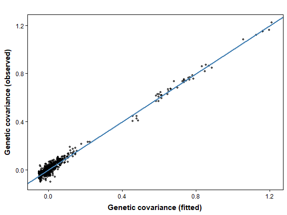

*Observed and fitted covariance in the site-centered representation.*

```r
plot(fit_wc, type = "fit")
```

Each point represents a pair of sites. The x-axis is the fitted covariance from the Wishart model; the y-axis is the observed covariance in the centered representation used by the contrast fit. Points near the diagonal indicate agreement for that summary, not calibrated sampling uncertainty.

### 9.2 Estimated conductance surface

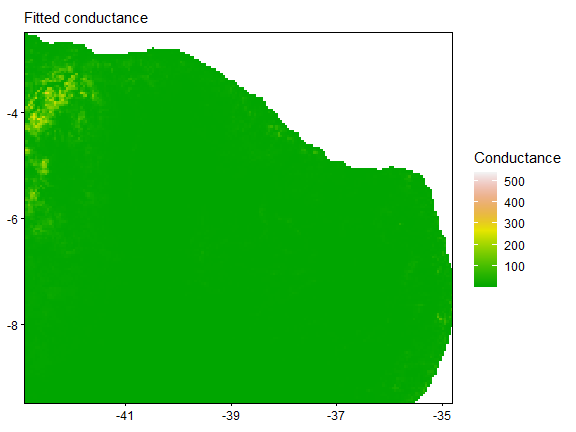

*Estimated conductance surface with 95% CI bounds.*

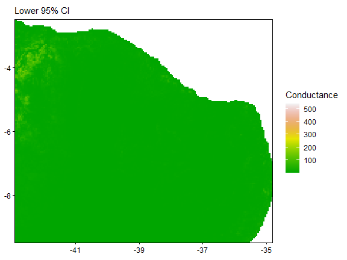

*Estimated conductance surface with 95% CI bounds.*

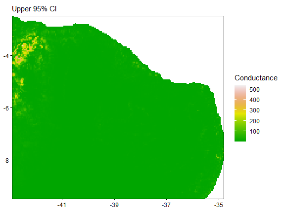

*Estimated conductance surface with 95% CI bounds.*

```r
plot(fit_wc, type = "surface", data = surface)
```

### 9.3 Marginal associations on conductance

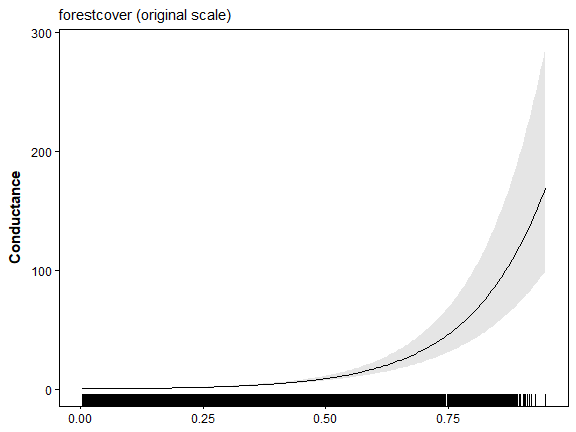

*Marginal associations on the fitted conductance scale.*

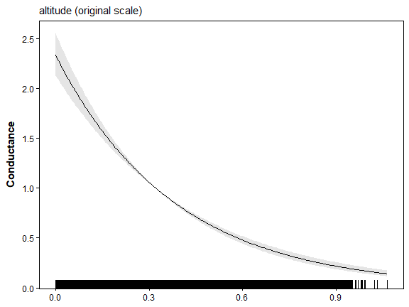

*Marginal associations on the fitted conductance scale.*

```r
plot(fit_wc, type = "marginal", data = surface)
```

Response-scale marginal plots are currently defined for regression-style measurement models such as `mlpe`. For covariance-response models, inspect the conductance-scale marginal associations alongside the observed-vs-fitted covariance plot above.

If one covariate has weak focal support at its tails, apply focal-support clamping during plotting and surface prediction:

```r
plot(
  fit_wc,
  type = "marginal",
  data = surface,
  support = "focal",
  support_probs = c(0.01, 0.99),
  clamp_covariates = c("forestcover", "altitude")
)

cond_wc_focal <- conductance(
  surface,
  fit_wc,
  support = "focal",
  support_probs = c(0.01, 0.99),
  clamp_covariates = c("forestcover", "altitude")
)
```

## 10 Preparing a generalized-Wishart squared-distance response

The generalized-Wishart likelihood expects a squared-distance response ${D = d^2}$, not an arbitrary symmetric dissimilarity matrix. For ${n}$ sites, `terradish` forms the centered Gram matrix

$$B = -\frac{1}{2} H D H, \qquad
H = I - \frac{1}{n}\mathbf{1}\mathbf{1}^{\mathsf T},$$

and requires ${B}$ to be positive semidefinite within a relative numerical tolerance. This geometry is the mathematical support condition for the likelihood. It is separate from whether the selected genetic summary is biologically appropriate for the sampling design and scientific question.

Use `check_distance_response()` on the matrix that you actually intend to fit:

```r
S_dist <- dist_from_cov(S_cov)
gw_check <- check_distance_response(S_dist)
gw_check[c("admissible", "relative_min_eigenvalue", "n_negative")]
```

```
#> $admissible
#> [1] TRUE
#>
#> $relative_min_eigenvalue
#> [1] 8.378367e-17
#>
#> $n_negative
#> [1] 0
```

**How to read the diagnostic:** `admissible = TRUE` means the implied centered Gram matrix is positive semidefinite within tolerance. A very small negative `relative_min_eigenvalue` can reflect floating-point rounding. `n_negative` counts only eigenvalues that are more negative than the scaled tolerance. `terradish()` performs this check automatically before any generalized-Wishart fit and stops on substantive violations.

The checker does not select a genetic distance for you. Choose the response based on the biology, marker type, sampling design, and intended interpretation, then test the realized matrix. The name of a distance measure is not enough because scaling, locus aggregation, transformations, and missing-data handling can change the resulting geometry.

### 10.1 Potentially relevant distance measures available in R

The table is a navigation aid, not a list of recommended or interchangeable responses. Functions can differ in their scaling, input class, treatment of missing data, and whether they operate on individuals or populations. Confirm what the selected function returns. If it returns ordinary Euclidean distances ${d}$, square the matrix to obtain ${D = d^2}$ before calling `check_distance_response()` or fitting `generalized_wishart`.

[output not shown]

`ade4::is.euclid()` provides an optional independent diagnostic for ordinary distances. Because it squares its input internally, the equivalent call for an already squared generalized-Wishart response `D` is:

```r
# D is already squared, so take its square root for ade4::is.euclid().
ade4::is.euclid(as.dist(sqrt(D)))
```

Do not call `ade4::is.euclid(as.dist(D))` for this purpose because that tests whether ${D^2}$, rather than ${D}$, has the required geometry. Functions such as `ade4::cailliez()` and `ade4::lingoes()` can make an ordinary distance matrix Euclidean for ordination, but `terradish` does not apply them automatically. They change the genetic response and can change its biological interpretation.

## 11 Compare with `generalized_wishart`

`generalized_wishart` uses the corresponding generalized Wishart formulation for an admissible **squared-distance** representation of the same genetic data. Here the response was obtained from the covariance matrix with `dist_from_cov()` and checked above:

```r
fit_gw <- terradish(
  S_dist ~ forestcover + altitude,
  data              = surface,
  conductance_model = loglinear_conductance,
  measurement_model = generalized_wishart,
  nu                = 1000
)

# Side-by-side parameter estimates
cat("wishart_covariance estimates:\n")
```

```
#> wishart_covariance estimates:
```

```r
print(round(coef(fit_wc), 3))
```

```
#> forestcover    altitude
#>       1.161      -0.531
```

```r
cat("\ngeneralized_wishart estimates:\n")
```

```
#>
#> generalized_wishart estimates:
```

```r
print(round(coef(fit_gw), 3))
```

```
#> forestcover    altitude
#>       1.161      -0.531
```

When the covariance and admissible squared-distance representations contain the same information under identical centering, scaling, sites, and `nu`, their fitted conductance parameters should agree up to numerical tolerance. The AIC comparison is not meaningful across the two models because the responses differ. Standard errors should only be compared after confirming that the transformation is lossless and the effective information assumptions are identical.

## 12 Choosing between covariance and distance input

| Consideration | Guidance |
| --- | --- |
| Raw genotype data available | Construct and document an appropriate covariance summary; assess filtering and unequal sampling. |
| Covariance and its matching squared distances available | Both Wishart interfaces use the same contrast likelihood. Choose the representation that makes preprocessing clearest. |
| Only a precomputed dissimilarity is available | Geometry is necessary but insufficient for Wishart sampling; consider MLPE for generic genetic distances. |
| Site-specific sampling variance matters | A common nugget does not fully address unequal sampling; examine design and sensitivity. |
| Effective information is uncertain | Declare a range of `nu`, rescale inference, and assess conductance complexity with held-out prediction. |

### 12.1 Environmental differences between sites

`pairwise_covariates()` combines geographic distances and endpoint environmental differences in one design. Both `mlpe_covariates()` and `wishart_covariates()` accept that design, while linking it to different response models. For Wishart, the nonnegative environmental kernel weights describe conditional contributions to covariance structure. They do not identify a particular biological mechanism. See `vignette("ibe-ibr-workflow", package = "terradish")` for a worked comparison, conditional conductance estimates, and IBE:IBR ratios.

## 13 Quick-reference: the full workflow

```r
library(terradish)
library(terra)

# 1. Load landscape data and build conductance surface
data(melip)
melip.altitude    <- terra::unwrap(melip.altitude)
melip.forestcover <- terra::unwrap(melip.forestcover)
melip.coords      <- terra::unwrap(melip.coords)

covariates <- c(melip.altitude, melip.forestcover)
names(covariates) <- c("altitude", "forestcover")
covariates <- scale_covariates(covariates)
surface <- conductance_surface(covariates, melip.coords, directions = 8)

# 2. Prepare the genetic covariance matrix from raw genotype data
#    (replace with your actual data and effective nu)

# Option A: biallelic SNPs (Y = derived allele counts, N = haploid totals)
S <- cov_from_biallelic(Y, N)

# Option B: individual-level numeric features grouped by population
S <- cov_from_genetic_data(dosage_matrix, groups = pop_vector,
                            normalize = "features")

# Option C: microsatellite allele calls
S <- cov_from_genetic_data(allele_df, groups = pop_vector,
                            input = "allele_calls",
                            loci  = locus_id_vector)

nu <- effective_marker_df  # justify, report, and evaluate sensitivity

# 3. Fit with wishart_covariance
fit <- terradish(
  S ~ forestcover + altitude,
  data              = surface,
  conductance_model = loglinear_conductance,
  measurement_model = wishart_covariance,
  nu                = nu
)

# 4. Summarize and visualize
summary(fit)
coef(fit)

plot(fit, type = "fit")
plot(fit, type = "surface", data = surface)
plot(fit, type = "marginal", data = surface)   # conductance-scale associations
```

## 14 Summary of key functions

| Function | Purpose |
| --- | --- |
| `cov_from_biallelic()` | Genetic covariance from SNP allele counts and sample sizes |
| `cov_from_genetic_data()` | Genetic covariance from dosages, PCA scores, or allele calls |
| `dist_from_cov()` | Convert a covariance matrix to the matching distance matrix |
| `wishart_covariance()` | Measurement model for a covariance response; needs `nu` |
| `check_distance_response()` | Diagnose squared-Euclidean admissibility of a proposed generalized-Wishart response |
| `generalized_wishart()` | Generalized Wishart likelihood for an admissible squared-distance response |
| `simulate_covariance_response()` | Simulate a covariance matrix from known parameters |
| `terradish()` | Fit the model and return coefficients, standard errors, and AIC |

## 15 See also

- **`vignette("getting-started", package = "terradish")`**, the core workflow using a distance response.
- **`vignette("simulation-design", package = "terradish")`**, how `nu` and sample size translate into statistical power before you collect data.
- **`vignette("ibe-ibr-workflow", package = "terradish")`**, adding environmental kernels to the Wishart likelihood with `wishart_covariates()`.